# ST1131 Introduction to Statistics and Statistical Computing

## Tutorial 7

```python
# Verify the notebook is using venv-st1131
# You should see either \venv-st1131\Scripts\python.exe or /venv-st1131/bin/python
import sys
from pathlib import Path
print(Path(*Path(sys.executable).parts[-3:]))
```

```
venv-st1131mac/bin/python
```

```python
# Verify required packages
import numpy as np
import pandas as pd
import matplotlib.pyplot as plt
from scipy import stats

print("Everything works!")
```

```
Everything works!
```

Some important functions we will use are:

- `stats.norm.ppf(q)` gives the $q$-th quantile of $N(0, 1)$, which we use as the multiplier $q_{1 - \alpha/2}$ for a confidence interval for a proportion.
- `stats.t.ppf(q, df)` gives the $q$-th quantile of the $t$-distribution with `df` degrees of freedom, which we use as the multiplier $t_{n-1,\,1-\alpha/2}$ for a confidence interval for a mean.
- `stats.t.interval(level, df, loc, scale)` returns a confidence interval for a mean directly, where `loc` is $\bar{X}$ and `scale` is the standard error $s/\sqrt{n}$.

### Question 1

A university surveys $600$ randomly selected students and asks whether they support extending the campus shuttle service to run past midnight. Of the $600$ students surveyed, $348$ say they support the extension.

Let $p$ denote the proportion of all students in the university who support the extension.

(a) Find the point estimate $\hat{p}$ of $p$, and check whether the condition $n\hat{p}(1 - \hat{p}) \ge 5$ is satisfied.

```python
n = 600
x = 348

p_hat = x / n
print(f"p_hat = {p_hat:.4f}")
print(f"n * p_hat * (1 - p_hat) = {n * p_hat * (1 - p_hat):.2f}")
```

```
p_hat = 0.5800
n * p_hat * (1 - p_hat) = 146.16
```

$$ \hat{p} = \frac{348}{600} = 0.58 $$

$$ n\hat{p}(1-\hat{p}) = 600(0.58)(0.42) = 146.16 \ge 5, $$

so the sampling distribution of $\hat{p}$ is approximately normal and we may form the confidence interval.

(b) Find the standard error of $\hat{p}$, the margin of error, and the $95$% confidence interval for $p$.

```python
se = np.sqrt(p_hat * (1 - p_hat) / n)
z_95 = stats.norm.ppf(0.975)
moe_95 = z_95 * se

print(f"Standard error = {se:.4f}")
print(f"Multiplier     = {z_95:.4f}")
print(f"Margin of error = {moe_95:.4f}")
print(f"95% CI = ({p_hat - moe_95:.4f}, {p_hat + moe_95:.4f})")
```

```
Standard error = 0.0201
Multiplier     = 1.9600
Margin of error = 0.0395
95% CI = (0.5405, 0.6195)
```

$$ SE = \sqrt{\frac{\hat{p}(1-\hat{p})}{n}} = \sqrt{\frac{0.58(0.42)}{600}} \approx 0.0201 $$

With $\alpha = 0.05$, the multiplier is $q_{0.975} \approx 1.96$, so the margin of error is

$$ 1.96(0.0201) \approx 0.0395, $$

and the $95$% confidence interval is

$$ 0.58 \pm 0.0395 = (0.5405,\ 0.6195). $$

Note that the quantile is taken at $1 - \alpha/2 = 0.975$, not at $0.95$. A common error is to use `stats.norm.ppf(0.95)`, which gives $1.645$ and produces a $90$% interval instead.

(c) Find the $99$% confidence interval for $p$. Compare its width with the width of the $95$% interval and explain the difference.

```python
z_99 = stats.norm.ppf(0.995)
moe_99 = z_99 * se

print(f"Multiplier = {z_99:.4f}")
print(f"99% CI = ({p_hat - moe_99:.4f}, {p_hat + moe_99:.4f})")
print(f"Width of 95% CI = {2 * moe_95:.4f}")
print(f"Width of 99% CI = {2 * moe_99:.4f}")
```

```
Multiplier = 2.5758
99% CI = (0.5281, 0.6319)
Width of 95% CI = 0.0790
Width of 99% CI = 0.1038
```

With $\alpha = 0.01$, the multiplier is $q_{0.995} \approx 2.576$, giving

$$ 0.58 \pm 2.576(0.0201) = (0.5281,\ 0.6319). $$

The $99$% interval has width $0.1038$ and the $95$% interval has width $0.0790$, so the $99$% interval is wider.

The sample is the same, so $\hat{p}$ and the standard error are unchanged. Only the multiplier changes. Being more confident that the interval captures $p$ requires casting a wider net, so a higher confidence level always gives a wider and less informative interval.

(d) A student writes:

> "There is a $95$% probability that $p$ lies between $0.5405$ and $0.6195$."

Is this interpretation correct? Briefly explain, and state the correct interpretation.

The interpretation is **not** correct. The population proportion $p$ is a fixed number, not a random variable. Once the interval has been computed from the data, either $p$ is inside it or it is not, so no probability is attached to that particular interval.

The confidence level describes the long-run performance of the **method**: if we repeatedly took random samples of $600$ students and formed a $95$% confidence interval from each sample, about $95$% of those intervals would contain the true value of $p$.

The usual wording is: we are $95$% confident that the proportion of all students who support the extension is between $0.5405$ and $0.6195$.

(e) Based on the intervals in parts (b) and (c), is there evidence that a majority of students support the extension? Briefly explain.

Yes. A majority means $p > 0.5$.

Both the $95$% interval $(0.5405,\ 0.6195)$ and the $99$% interval $(0.5281,\ 0.6319)$ lie entirely above $0.5$, so all the believable values of $p$ correspond to a majority. The conclusion still holds at the higher confidence level, which makes it more convincing.

Had the interval contained $0.5$, values below and above a majority would both be believable, and we could not draw this conclusion.

### Question 2

The university plans a new survey on the same question next year. They want a $95$% confidence interval for $p$ with a margin of error of at most $0.02$.

(a) Find the sample size needed, using the value of $p$ that gives the largest possible sample size. Explain why this value is used.

```python
D = 2 * 0.02   # margin of error 0.02 means width 0.04
z = stats.norm.ppf(0.975)

n_needed = (2 * z / D)**2 * 0.5 * (1 - 0.5)
print(f"n >= {n_needed:.2f}")
```

```
n >= 2400.91
```

A margin of error of at most $0.02$ means a width of at most $D = 0.04$. From

$$ n \ge \left(\frac{2q_{1-\alpha/2}}{D}\right)^2 p(1-p) = \left(\frac{2(1.96)}{0.04}\right)^2 (0.5)(0.5) \approx 2400.9, $$

the university needs at least **$2401$** students.

Since $p$ is unknown before the survey, we use $p = 0.5$. The product $p(1-p)$ is largest at $p = 0.5$, so this gives the largest required sample size. Any other value of $p$ would need a smaller sample, so planning with $p = 0.5$ guarantees the target margin of error whatever the true $p$ turns out to be.

(b) The university argues that since last year's survey gave $\hat{p} = 0.58$, they should use $p = 0.58$ in the calculation instead. Find the sample size this gives, and comment on the trade-off.

```python
n_needed_58 = (2 * z / D)**2 * 0.58 * (1 - 0.58)
print(f"n >= {n_needed_58:.2f}")
```

```
n >= 2339.45
```

$$ n \ge \left(\frac{2(1.96)}{0.04}\right)^2 (0.58)(0.42) \approx 2339.5, $$

so at least **$2340$** students, about $61$ fewer than before.

The saving is small because $p(1-p)$ changes slowly near $0.5$. The trade-off is that the guarantee now depends on the earlier estimate being roughly right. If the true $p$ is closer to $0.5$ than $0.58$, the margin of error will be slightly larger than $0.02$. Using $p = 0.5$ is the safe choice, and here it costs very little.

### Question 3

A nutritionist takes a random sample of $12$ ready meals from a supermarket chain and measures the sodium content of each. The sample mean is $480$ mg and the sample standard deviation is $95$ mg.

(a) Find the $95$% confidence interval for the population mean sodium content $\mu$.

```python
n_m = 12
x_bar = 480
s = 95

se_m = s / np.sqrt(n_m)
t_mult = stats.t.ppf(0.975, df=n_m - 1)
moe_m = t_mult * se_m

print(f"Standard error = {se_m:.4f}")
print(f"t multiplier (df = {n_m - 1}) = {t_mult:.4f}")
print(f"95% CI = ({x_bar - moe_m:.2f}, {x_bar + moe_m:.2f})")
```

```
Standard error = 27.4241
t multiplier (df = 11) = 2.2010
95% CI = (419.64, 540.36)
```

The standard error is

$$ \frac{s}{\sqrt{n}} = \frac{95}{\sqrt{12}} \approx 27.42. $$

With $df = n - 1 = 11$, the multiplier is $t_{11,\,0.975} \approx 2.201$, so

$$ 480 \pm 2.201(27.42) = (419.64,\ 540.36) \text{ mg}. $$

The degrees of freedom are $n - 1 = 11$, not $n = 12$.

(b) Find the interval obtained by using $1.96$ as the multiplier instead of the $t$-multiplier. Explain why $1.96$ is not appropriate when $n = 12$, and use the multipliers at $df = 11$, $29$ and $199$ to explain when using $1.96$ would be acceptable.

```python
moe_z = stats.norm.ppf(0.975) * se_m
print(f"Using 1.96: ({x_bar - moe_z:.2f}, {x_bar + moe_z:.2f})")

for df in [11, 29, 199]:
    print(f"df = {df:3d}: t multiplier = {stats.t.ppf(0.975, df):.4f}")
```

```
Using 1.96: (426.25, 533.75)
df =  11: t multiplier = 2.2010
df =  29: t multiplier = 2.0452
df = 199: t multiplier = 1.9720
```

Using $1.96$ gives $(426.25,\ 533.75)$, which is narrower than the correct interval.

The population standard deviation $\sigma$ is unknown and is estimated by $s$. That extra uncertainty is accounted for by the $t$-distribution, which has thicker tails than $N(0,1)$ and therefore a larger multiplier. Using $1.96$ understates the margin of error, so the interval is too narrow and the method would capture $\mu$ less than $95$% of the time.

The gap shrinks as the degrees of freedom grow: the multiplier is $2.201$ at $df = 11$, $2.045$ at $df = 29$ and $1.972$ at $df = 199$. For large samples, the $t$-multiplier is close to $1.96$, which is why the two approaches would give similar intervals. At $df = 199$, the difference is negligible.

(c) State the assumptions required for this interval to be valid, and comment on how seriously each one matters here.

Two assumptions are required.

1. **The sample is obtained by randomization.** This holds here, since the meals were sampled at random. The method is **not** robust to this assumption. If the nutritionist had picked the $12$ meals by convenience, no sample size would fix the resulting bias.
2. **The data distribution is approximately normal or symmetric.** We cannot check this from summary statistics alone, so we would want to see a histogram of the $12$ measurements. The method is fairly robust to this assumption, but with $n = 12$ the sample is small, so strong skew or an extreme outlier would be a real concern. With a large sample we would only need to check for extreme outliers.

### Question 4

A survey asked respondents: "On an average day, about how many hours of television do you personally watch?" The responses from a random sample of adults are stored in the file `TVhours.csv`, which has a single column `hours`.

Let $\mu$ denote the mean number of hours of television watched per day in the population.

(a) Read the data into Python. Report the sample size, the sample mean and the sample standard deviation.

```python
tv = pd.read_csv("../data/TVhours.csv")

n_tv = len(tv)
mean_tv = tv["hours"].mean()
sd_tv = tv["hours"].std()

print(f"n    = {n_tv}")
print(f"mean = {mean_tv:.4f}")
print(f"sd   = {sd_tv:.4f}")
print()

# Alternatively, using numpy:
tvn = len(tv["hours"])
tvmean = np.mean(tv["hours"])
tvsd = np.std(tv["hours"], ddof=1)

print(f"Sample size = {tvn}")
print(f"Sample mean = {tvmean:.4f}")
print(f"Sample standard deviation = {tvsd:.4f}")
```

```
n    = 60
mean = 2.6167
sd   = 1.7954

Sample size = 60
Sample mean = 2.6167
Sample standard deviation = 1.7954
```

The sample size is $n = 60$, the sample mean is $\bar{X} \approx 2.6167$ hours and the sample standard deviation is $s \approx 1.7954$ hours.

Note that `pandas` uses `ddof=1` by default, which is the sample standard deviation we want. `numpy` defaults to `ddof=0`, so `np.std(tv["hours"])` would give a slightly smaller value and the wrong standard error.

(b) Plot a histogram of the hours of television watched. Comment on the shape of the distribution and on whether the confidence interval method is appropriate here.

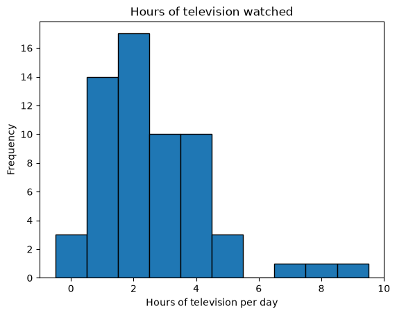

```python
plt.hist(tv["hours"], bins=np.arange(-0.5, tv["hours"].max() + 1.5, 1), edgecolor="black")
plt.xlabel("Hours of television per day")
plt.ylabel("Frequency")
plt.title("Hours of television watched")
plt.show()
```

The distribution is **right-skewed**. Most respondents report $1$ to $4$ hours, with a small number reporting $7$ to $9$ hours, and it is bounded below by $0$.

The data are therefore not normally distributed. This is acceptable: the method is robust to the normality assumption, and with $n = 60$ the sample is reasonably large, so we only need to check that there are no extreme outliers. The largest values of $7$ to $9$ hours are plausible answers rather than recording errors, so we proceed.

Note that the interval estimates the **population mean**, not the distribution of individual responses. Skewness in the data does not make the mean a meaningless target.

(c) Give a point estimate of $\mu$, and find the standard error of this estimate.

```python
se_tv = sd_tv / np.sqrt(n_tv)
print(f"Point estimate of mu = {mean_tv:.4f}")
print(f"Standard error       = {se_tv:.4f}")
```

```
Point estimate of mu = 2.6167
Standard error       = 0.2318
```

The point estimate of $\mu$ is the sample mean, $\bar{X} \approx 2.6167$ hours.

Its standard error is

$$ \frac{s}{\sqrt{n}} = \frac{1.7954}{\sqrt{60}} \approx 0.2318. $$

The standard deviation $s \approx 1.80$ describes how much individual people differ. The standard error $\approx 0.23$ describes how much the sample mean would vary from sample to sample, and it is the quantity used in the confidence interval.

(d) Find the margin of error and the $95$% confidence interval for $\mu$. Verify your answer using `stats.t.interval()`, and interpret the interval.

```python
t_tv = stats.t.ppf(0.975, df=n_tv - 1)
moe_tv = t_tv * se_tv

print(f"t multiplier (df = {n_tv - 1}) = {t_tv:.4f}")
print(f"Margin of error = {moe_tv:.4f}")
print(f"95% CI = ({mean_tv - moe_tv:.4f}, {mean_tv + moe_tv:.4f})")

lower, upper = stats.t.interval(0.95, df=n_tv - 1, loc=mean_tv, scale=se_tv)
print(f"Using stats.t.interval: ({lower:.4f}, {upper:.4f})")
```

```
t multiplier (df = 59) = 2.0010
Margin of error = 0.4638
95% CI = (2.1529, 3.0805)
Using stats.t.interval: (2.1529, 3.0805)
```

With $df = 59$, the multiplier is $t_{59,\,0.975} \approx 2.001$, so the margin of error is

$$ 2.001(0.2318) \approx 0.4638, $$

and the $95$% confidence interval is

$$ 2.6167 \pm 0.4638 = (2.1529,\ 3.0805). $$

`stats.t.interval()` returns the same interval.

We are $95$% confident that the mean number of hours of television watched per day in the population is between about $2.15$ and $3.08$ hours.

(e) A follow-up study wants a $95$% confidence interval for $\mu$ with width at most $0.3$ hours. Using the sample standard deviation above as an estimate of $\sigma$, find the required sample size.

```python
D_tv = 0.3
n_follow = (2 * stats.norm.ppf(0.975) * sd_tv / D_tv)**2
print(f"n >= {n_follow:.2f}")
```

```
n >= 550.34
```

$$ n \ge \left(\frac{2q_{1-\alpha/2}\,s}{D}\right)^2 = \left(\frac{2(1.96)(1.7954)}{0.3}\right)^2 \approx 550.34, $$

so the follow-up study needs at least **$551$** respondents.

We use the normal quantile $1.96$ rather than a $t$ quantile because the degrees of freedom depend on $n$, which is exactly what we are trying to find. This is the only situation in which we approximate the multiplier this way, and the approximation is safe as long as the resulting $n$ is at least $30$.

The current sample of $60$ gives a width of about $0.93$, so cutting the width to $0.3$, roughly a third, requires about nine times the sample size. Halving the width always costs four times the sample size, since the width depends on $\sqrt{n}$.

### Question 5

This question illustrates what the confidence level actually means.

Suppose the true proportion of students supporting the shuttle extension is $p = 0.58$, and that we repeatedly take random samples of $n = 600$ students.

(a) Using `np.random.seed(1131)`, simulate $1000$ such samples with `np.random.binomial()`. For each sample, compute $\hat{p}$ and form a $95$% confidence interval for $p$. Find the proportion of the $1000$ intervals that contain the true value $p = 0.58$.

```python
np.random.seed(1131)

p_true, n_sim, reps = 0.58, 600, 1000
p_hats = np.random.binomial(n_sim, p_true, size=reps) / n_sim

se_sim = np.sqrt(p_hats * (1 - p_hats) / n_sim)
lower = p_hats - stats.norm.ppf(0.975) * se_sim
upper = p_hats + stats.norm.ppf(0.975) * se_sim

contains = (lower <= p_true) & (p_true <= upper)
print(f"Proportion of intervals containing p = {contains.mean():.3f}")
```

```
Proportion of intervals containing p = 0.955
```

**$0.955$**, or $95.5$% of the $1000$ intervals contain the true value $p = 0.58$. This is close to the nominal $95$%, and the difference is due to simulation variability and the normal approximation to the sampling distribution of $\hat{p}$.

(b) Explain how this result relates to the interpretation you gave in Question 1(d).

Each simulated sample gives a different $\hat{p}$ and therefore a different interval. Some of those intervals contain $p = 0.58$ and some do not, and which happens is decided by the sample, not by $p$.

The confidence level is the proportion of intervals produced by the method that capture the parameter over many repetitions, which is what the simulation measures directly. In practice we only ever collect one sample and so see one of these intervals, and we never know whether ours is one of the roughly $95$% that succeed or one of the $5$% that miss. That is exactly why the statement in Question 1(d) is about the method rather than about a particular interval.